# `ggplot2`(gg = **G**rammar of **G**raphics) Summary

## Key components of every plot

1. **Data**
2. [**Aesthetic mapping**](https://htmlpreview.github.io/?https://github.com/kwhkim/MJU-2018-02-DataScience/blob/master/00_Instructor/W07_ggplot2/ggplot2_aes.html)
   - `mapping` : which aesthetics to use
     - `x`, `y`, `+ facet_grid(y ~ x)` and `+ fact_wrap(~g)`
     - `color`, `fill`
     - `shape`
     - `size`
     - `alpha` : usu. for avoid overplotting
   - `scale` : how to map
     - `x`, `y` : `scale_x_log10()`, `scale_x_reverse()`, `scale_x_sqrt()`
     - discrete `color`, `fill`
       - `scale_fill_brewer(palette= )`
       - `scale_fill_grey(start= , end= , na.value= )`
     - continous `color`, `fill`
       - `scale_fill_distiller(palette= )`
       - `scale_fill_gradient(low= , high= )`
       - `scale_fill_gradient(low= , high= , mid= , midpoint= )`
       - `scale_fill_gradientn(colours= )`
     - general
       - `scale_*_manual(values= )`
       - `scale_*_date(date_labels="%m/%d")`
       - `scale_*_datetime()`
3. [**Geoms**](https://htmlpreview.github.io/?https://github.com/kwhkim/MJU-2018-02-DataScience/blob/master/00_Instructor/W07_ggplot2/ggplot2_geoms.html)
   - one instance geoms (ex. `point`, `jitter`, `rug`, `col`, `label`, `text`)
   - summary geoms
     - 1 variable distribution : `density`, `histogram`, `barplot`
     - 1 variable distribution conditional on another variable : `boxplot`, `violin`
     - 2 variable distribution : `density2d`, `bin2d`, `hex`
     - model : `smooth`, `quantile`
4. [**Auxillary lines**](https://htmlpreview.github.io/?https://github.com/kwhkim/MJU-2018-02-DataScience/blob/master/00_Instructor/W07_ggplot2/ggplot2_lines.html)
   - `geom_hline(yintercept= , col= , size= , linetype= )`
   - `geom_vline(xintercept= , col= , size= , linetype= )`
   - `geom_abline(intercept= , col= , slope= )`

linetypes

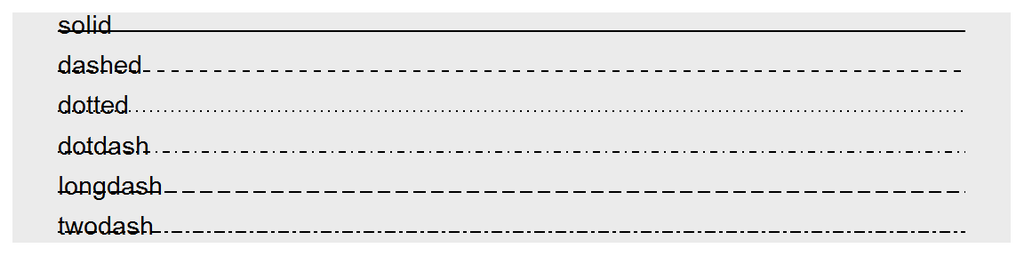

5. [**Coordinate System**](https://htmlpreview.github.io/?https://github.com/kwhkim/MJU-2018-02-DataScience/blob/master/00_Instructor/W07_ggplot2/ggplot2_coord.html)
   - Coordinate System
     - Cartesian vs. Polar
     - `coord_fixed(ratio = )`, `coord_flip()`, `coord_trans()`
     - `coord_quickmap()`, `coord_map()`
   - Coordinate label
     - `+ labs(x=' ', y=' ')`
   - Breaks & Labels
     - `scale_x_continuous(breaks=c())`
     - `scale_x_continuous(labels=c())` or `scale_x_continuous(labels=NULL)`
   - Zooming
     - Without clipping : `coord_cartesian(xlim = c( , ), ylim = c( , ))`
     - With clipping
       - `+ xlim( , ) + ylim( , )`
       - `+ scale_x_continuous(limits=c( , ))+scale_y_continuous(limits=c( , ))`
     - `scale_x_continuous(labels=c())` or `scale_x_continuous(labels=NULL)`
6. [**Legends**](https://htmlpreview.github.io/?https://github.com/kwhkim/MJU-2018-02-DataScience/blob/master/00_Instructor/W07_ggplot2/ggplot2_legend.html)
   - legend title : `+ scale_x_continous(name=' ')`
   - position : `+ theme(legend.position='bottom')`
     - `top`, `left`, `bottom`, `right`
   - legend type : `+ guides(fill=' ')`
     - `none`, `colorbar`, `legend`
   - legend label : `+ scale_x_continuous(labels=c())`
7. [**Title, subtitle, caption and themes**](https://htmlpreview.github.io/?https://github.com/kwhkim/MJU-2018-02-DataScience/blob/master/00_Instructor/W07_ggplot2/ggplot2_title.html)
   - title : `labs(title=' ')`
   - subtitle : `labs(subtitle=' ')`
   - caption : `labs(cpation=' ')`
   - themes
     - `+ theme_bw()`
     - `+ theme_gray()`
     - `+ theme_dark()`
     - `+ theme_class()`
     - `+ theme_light()`
     - `+ theme_linedraw()`
     - `+ theme_minimal()`
     - `+ theme_void()`

### 참고자료

- RStudio - Help - Cheatsheets - Data Visualization with ggplot2
- [R Bookdown](https://bookdown.org/)
  - [Data Visualization](https://socviz.co/)
  - [Fundamentals of Data Visualization](https://serialmentor.com/dataviz/)
  - [R for Data Science](http://r4ds.had.co.nz/)
- ggplot2-book
- [Top 50 ggplot2 Visualizations](http://r-statistics.co/Top50-Ggplot2-Visualizations-MasterList-R-Code.html)